# GIS-Clinical Collaboration: Web-based Report

Martin Gleason, MS

02/13/2020

## The Ask

The purpose of this report is to answer a question posed by DCPO Halawa and Data Analyst Loftus: Would be possible to use the [Cook County Medical Examiner Office](https://maps.cookcountyil.gov/medexammaps/) (ME) data to supplement the department’s internal tracking of justice involved youth killed in gun-related incidents within Cook County?

It would violate the [Juvenile Court Act](http://www.ilga.gov/legislation/ilcs/ilcs3.asp?ActID=1863&ChapterID=50) to reveal any personal data, including names or addresses, of justice involved youth. This includes sharing addresses with other county departments without the expressed permission of the Chief Judge. The work done by DCPO Halawa and Data Analyst Loftus, then, cannot be joined with the ME’s data. Therefore, this report’s scope has been limited to the creation of a web-based document that maps and tracks the department’s key performance indicators from the ME’s publicly available data. Next steps and potential barriers are also addressed, in order to make the next phase of this project “shovel-ready.”

A web-based version of this report can be found by following this [link](https://martin-gleason.github.io/gis_clinical/report_git.html).

### Importing the Data

Importing the medical examiner’s (ME) office data is a simple task: The [Cook County Open Data website](https://datacatalog.cookcountyil.gov) has a link that, when incorporated into the `R` code of the report, allows for direct connection to the Open Data Portal. This eliminates the need of downloading files, ensures the most up-to-date data, and simplifies the data cleaning process.

### Cleaning Data

Even though this data is coming from directly from the Medical Examiner’s database, the data does need to be cleaned. This process adds, or removes, features of the data in order to focus on the department’s key performance indicators. Exploring the data in a tabular format assists in determining how to modify the features.

Medical Examiner’s Office Data: 02/13/2020

| casenumber | incident_date | death_date | age | gender | race | latino | manner | primarycause | gunrelated | opioids | incident_street | longitude | latitude | objectid | location.type | location.coordinates | cold_related | heat_related | residence_zip | incident_zip | secondarycause | primarycause_lineb | primarycause_linec | residence_city | incident_city |
| --- | --- | --- | --- | --- | --- | --- | --- | --- | --- | --- | --- | --- | --- | --- | --- | --- | --- | --- | --- | --- | --- | --- | --- | --- | --- |
| ME2014-00627 | 1411311600 | 1411325400 | 25 | Male | Black | FALSE | UNDETERMINED | DROWNING | FALSE | FALSE | 499 E. North Water St. | -87.61544627360976 | 41.889496395313714 | 48783 | Point | c(-87.6154462736098, 41.8894963953137) | NO | NO | 60608 | NA | NA | NA | NA | NA | NA |
| ME2014-00649 | 1411422000 | 1411422900 | 61 | Male | Black | FALSE | NATURAL | HYPERTENSIVE ARTERIOSCLEROTIC CARDIOVASCULAR DISEASE | FALSE | FALSE | 1317 PORTLAND | -87.62341681025514 | 41.507404983299956 | 48784 | Point | c(-87.6234168102551, 41.5074049833) | NO | NO | 60411 | 60411 | NA | NA | NA | NA | NA |
| ME2014-00712 | 1411855080 | 1411855800 | 51 | Male | White | FALSE | NATURAL | DIABETIC KETOACIDOSIS | FALSE | FALSE | 8759 PELIKIN | -87.84975118706316 | 41.77358560899294 | 48785 | Point | c(-87.8497511870632, 41.7735856089929) | NO | NO | 60525 | 60525 | NA | NA | NA | NA | NA |
| ME2014-00792 | 1412226000 | 1412277300 | 55 | Male | Black | FALSE | NATURAL | HYPERTENSIVE AND ARTERIOSCLEROTIC CARDIOVASCULAR DISEASE | FALSE | FALSE | 7750 South Emerald | -87.64296492621112 | 41.75335744449129 | 48786 | Point | c(-87.6429649262111, 41.7533574444913) | NO | NO | NA | NA | NA | NA | NA | NA | NA |

For the department’s purposes, a number of features should be manipulated to keep the data clean. The department needs to focus on a particular age range – up to age 26 – and gun-related incidents. Another feature is the race of the young person. The ME’s office tracks race in the following way: Black, White, Other, Asian, NA, Unknown, Am. Indian, with Latino being listed as a separate, binary column. For the department’s needs, the ME’s data needs to add Latino to race. This is a simple cleaning function in R, that creates the follow categories: Black, White, Other, Asian, NA, Unknown, White Latino, Latino, Am. Indian, Black Latino, NA Latino, Unknown Latino, Am. Indian Latino, Asian Latino

### Visualizing the Data

The cleaned ME data set has following 27 columns: *casenumber, incident_date, death_date, age, gender, race, latino, manner, primarycause, gunrelated, opioids, incident_street, longitude, latitude, objectid, location.type, location.coordinates, cold_related, heat_related, residence_zip, incident_zip, secondarycause, primarycause_lineb, primarycause_linec, residence_city, incident_city, source*. Displaying all of this data in a single column is not useful on paper, but because this report is web based, we can add scroll bars to the table in order to view all the entries.

Medical Examiner’s Office Data 02/13/2020

| casenumber | incident_date | death_date | age | gender | race | latino | manner | primarycause | gunrelated | opioids | incident_street | longitude | latitude | objectid | location.type | location.coordinates | cold_related | heat_related | residence_zip | incident_zip | secondarycause | primarycause_lineb | primarycause_linec | residence_city | incident_city | source |
| --- | --- | --- | --- | --- | --- | --- | --- | --- | --- | --- | --- | --- | --- | --- | --- | --- | --- | --- | --- | --- | --- | --- | --- | --- | --- | --- |
| ME2017-02502 | 1496301060 | 1496356080 | 19 | Male | Black | FALSE | HOMICIDE | GUNSHOT WOUND OF HEAD | TRUE | FALSE | intersection of andover and revere | NA | NA | 49395 | NA | NULL | NO | NO | 60411 | 60411 | NA | NA | NA | Sauk Village | CHICAGO HEIGHTS | Medical Examiner |
| ME2017-00331 | 1484773200 | 1484867640 | 19 | Male | Black | FALSE | HOMICIDE | GUNSHOT WOUND OF TORSO | TRUE | FALSE | 4200 GEORGIA STREET | NA | NA | 49479 | NA | NULL | NO | NO | 46410 | 46409 | NA | NA | NA | Merrillville | GARY | Medical Examiner |
| ME2017-02072 | 1494136800 | 1494170100 | 21 | Male | White | FALSE | SUICIDE | GUNSHOT WOUND OF HEAD | TRUE | FALSE | 1860 S ARLINGTON HTS RD | -87.98399339672822 | 42.05188610113801 | 49481 | Point | c(-87.9839933967282, 42.051886101138) | NO | NO | 60067 | 60005 | NA | NA | NA | Palatine | ARLINGTON HEIGHTS | Medical Examiner |
| ME2017-02406 | 1495901700 | 1495903620 | 16 | Male | Black | FALSE | HOMICIDE | GUNSHOT WOUNDS OF THE CHEST | TRUE | FALSE | 11 N. Madion Street | NA | NA | 49585 | NA | NULL | NO | NO | 60612 | 60302 | NA | NA | NA | Chicago | OAK PARK | Medical Examiner |
| ME2017-00581 | 1486167600 | 1486169280 | 26 | Male | White Latino | TRUE | HOMICIDE | GUNSHOT WOUND OF CHEST | TRUE | FALSE | MAPLE EAST OF JACKSON | NA | NA | 49589 | NA | NULL | NO | NO | 60139 | 60303 | NA | NA | NA | Glendale Heights | OAK PARK | Medical Examiner |
| ME2017-05649 | 1512277140 | 1512278940 | 23 | Male | Black | FALSE | HOMICIDE | MULTIPLE GUNSHOT WOUNDS | TRUE | FALSE | 7201 W. NORTH AVE | -87.80634190943427 | 41.90857041261212 | 49590 | Point | c(-87.8063419094343, 41.9085704126121) | NO | NO | NA | 60305 | NA | NA | NA | NA | RIVER FOREST | Medical Examiner |
| ME2017-00242 | 1484365440 | 1484404200 | 20 | Male | Black | FALSE | HOMICIDE | GUNSHOT WOUND OF HEAD | TRUE | FALSE | S Orchard Rd And Cornell Ave | NA | NA | 49678 | NA | NULL | NO | NO | 60506 | 60538 | NA | NA | NA | Aurora | MONTGOMERY | Medical Examiner |
| ME2017-00795 | 1486608120 | 1487179200 | 25 | Male | Black | FALSE | HOMICIDE | GUNSHOT WOUND OF BACK | TRUE | FALSE | 345 S Canal St | -87.63962853261914 | 41.888229470064914 | 49692 | Point | c(-87.6396285326191, 41.8882294700649) | NO | NO | 55443 | 60606 | NA | NA | NA | Minneapolis | CHICAGO | Medical Examiner |
| ME2017-03878 | 1503212280 | 1503213660 | 22 | Male | Black | FALSE | HOMICIDE | MULTIPLE GUNSHOT WOUNDS | TRUE | FALSE | 1042 WEST MAXWELL | -87.6526164063243 | 41.864741147421995 | 49753 | Point | c(-87.6526164063243, 41.864741147422) | NO | NO | 60608 | NA | NA | NA | NA | Chicago | CHICAGO | Medical Examiner |
| ME2017-00986 | 1488093540 | 1488097620 | 18 | Male | White Latino | TRUE | HOMICIDE | GUNSHOT WOUND OF BACK | TRUE | FALSE | 10942 S MACKINAW | -87.54263853026504 | 41.69653877254677 | 49789 | Point | c(-87.542638530265, 41.6965387725468) | NO | NO | 60617 | 60617 | NA | NA | NA | Chicago | CHICAGO | Medical Examiner |

A more useful way of displaying the data is summarizing by categories:

2017 Shooting Data Summarized

| manner | race | gender | Total |
| --- | --- | --- | --- |
| HOMICIDE | Black | Female | 26 |
| HOMICIDE | Black | Male | 303 |
| HOMICIDE | Black Latino | Male | 2 |
| HOMICIDE | Latino | Male | 2 |
| HOMICIDE | Other | Male | 3 |
| HOMICIDE | White | Female | 1 |
| HOMICIDE | White | Male | 6 |
| HOMICIDE | White Latino | Female | 5 |
| HOMICIDE | White Latino | Male | 65 |
| SUICIDE | Black | Male | 13 |
| SUICIDE | White | Female | 4 |
| SUICIDE | White | Male | 11 |
| SUICIDE | White Latino | Female | 1 |
| SUICIDE | White Latino | Male | 4 |
| UNDETERMINED | Black | Male | 2 |

And by plotting the data.

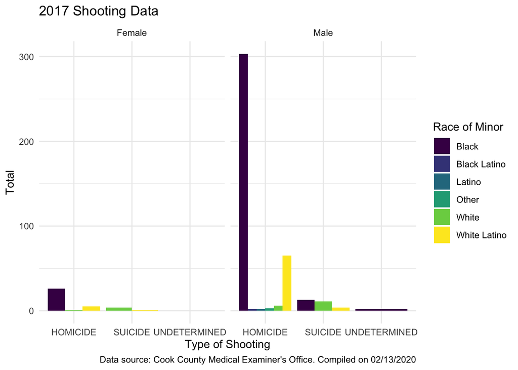

In short, the data can be filtered, selected and summarized for [descriptive statistics](https://en.wikipedia.org/wiki/Descriptive_statistics), or displayed as a variety of graphs. Additionally, this data can be combined with internal data sets maintained by the department to determine what, if any, connections exist between youth who were killed in gun-related incidents and department programs and interventions. Adding this layer of data, while beyond the scope of this report, is well within the capability of the Office of the Chief Judge and the Department. With the impending release of the new case management system, [cFive Supervisor](https://www.cfive.com/products/supervisor/), extending reporting features should be explored in post go-live projects.

## GIS

Extending department capability with Geographic Information Systems (GIS) is another feature that can be added to the department’s analytic capability. The ME’s office already uses Cook County’s GIS (CCGIS) department to map all deaths in the county; however, the department has other geographic areas of interest. These include: police district, judicial district, Cook County Commissioner District and a yet-to-be-defined *probation district.* The [Cook County Medical Examiner Office](https://maps.cookcountyil.gov/medexammaps/)(ME) GIS dashboards present an impressive starting point for the department’s own GIS enabled reports.

It is well within the capacity of the department and CCGIS to build more interactive web reports. The barriers to this are policy driven, not technical. CCGIS needs sample data of at least 500 records to design our dashboards and reports, and the Office of the Chief Judge (OCJ) prefers to keep all data on it’s own servers. While negotiations between OCJ and CCGIS are ongoing, to demonstrate the basic capability of this type of analysis, this prototype report will show gun-related incidents per Cook County Commissioner Districts for the department’s age-range.

### Shooting Incidents of 15-26 Year-Olds by Cook County Commissioner District: 2016 - Today

[interactive chart not shown]

Cook County Shooting Incidents by Comminsioner District: 2016 - Today. Source Cook County Medical Examiner’s Office

## Displaying Reports

Using the data and methods contained in this document, creating a GIS-informed report that runs regularly would be a relatively simple task. Creating a dashboard or app to display the same data would only be marginally more intensive. It would require installing `R` and `RStudio` on the Chief Judge’s servers. Given that OCJ has already begun the process of deploying Linux servers to support the new case plan system, adding another Linux instance on the OCJ intranet is neither a technical nor a cost prohibitive step. The most pressing concern about a dashboard/app would be getting permission from County stakeholders to share data between departments and approve the use of an internal web server.

The advantages of a dashboard/app would be the ability to filter the data sets and display them in real time, instead of “hard coding” results like this report. This method would increase collaboration, free up staff time for other analysis, generate less paper, and allow for easy access for all OCJ staff. These tools would also supplement the dashboard and report ability of the department’s new case management system, [cFive](https://www.cfive.com/products/supervisor/). cFive’s demonstrated dashboards, while customizable, do not have the same capabilities (GIS, importing ME data, etc) as this report. The methods demonstrated in this prototype can be directly applied to cFive’s reporting structure.

## Recap and Next Steps

Medical Examiner office and juvenile court data can be easily combined to track and measure shooting deaths of court involved youth. Collecting, cleaning, and visualizing this data was demonstrated in this prototype; furthermore, this solution can be deployed to the department shortly after cFive’s reporting system goes live. Expanding this capacity into dashboards is possible with a minor addition to the OCJ’s infrastructure.

The barrier to dashboard development is ensuring that the dashboards are not accessible to the public. While this is a technical issue that is beyond the scope of this report, the Office of the Chief Judge has already begun to deploy an additional server to host cFive’s reporting services that would not be available for public consumption. An additional Linux server, configured to host dashboards and R functionality, would be a mid-tier IT project that could dramatically increase the department’s analytic capability without cost to the department’s capital expenditures. Such a project is the logical next step of this analysis, and can begin immediately after cFive’s reporting feature goes live.